# 1.1 The Journey from Traditional BI to Modern Analytics

## Evolution of Business Intelligence

Business Intelligence has undergone a remarkable transformation over the past few decades, evolving from static reporting tools to dynamic, interactive analytics platforms. This evolution reflects the changing needs of organizations and the rapid advancement of technology.

### The Traditional BI Era (1990s-2000s)

In the early days of Business Intelligence, solutions were characterized by:

- **IT-Centric Architecture**: Specialized IT departments maintained control over BI tools and infrastructure
- **Batch Processing**: Reports were generated on scheduled intervals rather than on-demand
- **Predefined Reports**: End users relied on pre-built reports with limited customization options
- **Data Warehousing Focus**: Heavy emphasis on centralized data repositories
- **Complex Implementation**: Deployment cycles of months or years before delivering value
- **Limited Self-Service**: Business users remained dependent on technical specialists

These systems, while groundbreaking at the time, created bottlenecks as organizations’ data volumes grew and business users demanded more timely insights.

### The Modern Analytics Revolution (2010s-Present)

The modern era of business intelligence represents a fundamental shift in approach:

- **Business-User Empowerment**: Self-service capabilities that reduce IT dependencies
- **Real-Time Processing**: On-demand analysis with near-instantaneous results
- **Interactive Visualization**: Dynamic dashboards that respond to user input
- **Cloud-Native Architecture**: Scalable solutions that grow with organizational needs
- **Mobile Accessibility**: Analytics available across devices and locations
- **Embedded Analytics**: BI capabilities integrated directly into business applications
- **AI-Enhanced Insights**: Machine learning augmenting human analysis

This evolution reflects broader technology trends, including cloud computing, mobile technology, artificial intelligence, and the democratization of data access.

## Key Drivers of BI Transformation

Several critical factors have accelerated the transformation of business intelligence:

1. **Explosive Data Growth**: Organizations now generate and collect data at unprecedented rates, necessitating more sophisticated analysis tools
2. **Rising Data Literacy**: Business users have become more proficient with data, increasing demand for self-service capabilities
3. **Competitive Pressure**: Market dynamics require faster decision-making backed by data
4. **Technology Advancements**: Improvements in computing power, storage, and visualization techniques
5. **Changing Workforce Expectations**: Modern workers expect intuitive, consumer-grade experiences in enterprise software

## The Current BI Landscape

Today’s business intelligence landscape is characterized by several key trends:

- **Platform Consolidation**: Organizations seeking to reduce the number of disparate tools
- **Low-Code/No-Code Solutions**: Expanding analytics access to non-technical users
- **Augmented Analytics**: AI-powered features that guide users to insights
- **Data Storytelling**: Moving beyond visualizations to coherent analytical narratives
- **Collaborative Analysis**: Team-based approaches to data exploration and insight sharing
- **Ethical AI and Data Governance**: Growing focus on responsible analytics practices

As the field continues to evolve, the line between traditional business intelligence, advanced analytics, and performance management continues to blur, creating opportunities for more integrated approaches.

## The Rise of Self-Service Analytics

Perhaps the most significant shift in modern BI has been the move toward self-service analytics, which encompasses:

- **Intuitive Interfaces**: Visual, drag-and-drop environments that require minimal training
- **Natural Language Processing**: Ability to query data using conversational language
- **Guided Analytics**: Systems that recommend visualizations and insights
- **Simplified Data Preparation**: User-friendly tools for data cleaning and transformation
- **Visual Data Exploration**: Interactive methods for discovering patterns and outliers

This self-service revolution has dramatically reduced the time from question to insight, enabling organizations to be more agile and data-driven.

## The Next Frontier: Unified Analytics Platforms

As we look toward the future, the next evolution in business intelligence involves unified platforms that seamlessly integrate:

- **Reporting**: Communicating what happened
- **Analytics**: Understanding why it happened
- **Planning**: Determining what should happen next
- **Prediction**: Forecasting what will happen

This unified approach addresses the fragmentation that often exists when these functions are handled by separate systems, creating a more cohesive and efficient analytics experience.

In the following sections, we’ll explore how Inforiver Analytics+ represents this next frontier, addressing the limitations of both traditional BI tools and modern visualization platforms while delivering an integrated solution for the contemporary data-driven organization.

# 1.2 Limitations of Native Power BI Visuals

Microsoft Power BI has established itself as a leading business intelligence platform, offering organizations powerful tools for data visualization and analysis. However, as organizations’ analytics needs grow in sophistication, users often encounter limitations with native Power BI visualizations that can restrict their ability to create truly effective, enterprise-grade dashboards and reports.

## Visualization Variety Constraints

Despite continual improvements, Power BI’s native visualization library presents several limitations:

- **Limited Chart Selection**: While Power BI offers essential visualization types, many specialized chart types required for specific analysis scenarios remain unavailable natively
- **Basic Small Multiples Support**: Native small multiples (also known as trellis charts) have limitations in flexibility and configuration options
- **Restricted Financial Visualizations**: Limited support for specialized financial and variance analysis charts that adhere to established reporting standards
- **Minimal Statistical Visualizations**: Few built-in options for statistical analysis visualizations like box plots, histograms with distribution curves, or specialized correlation visualizations
- **Standardization Challenges**: Difficulty in establishing and maintaining consistent visual standards across reports

Organizations requiring advanced visualization types must often resort to custom development or third-party visuals, leading to inconsistency and additional technical overhead.

## Data Volume Handling

One of the most significant technical limitations of native Power BI visuals involves data handling capacity:

- **Data Point Limitations**: Native visuals typically handle approximately 3,500 data points effectively, creating performance issues with larger datasets
- **Sampling Mechanisms**: When datasets exceed thresholds, automatic sampling occurs, potentially obscuring valuable insights
- **Rendering Performance**: Degraded performance with complex visualizations and larger datasets
- **Memory Constraints**: Inefficient memory utilization leading to browser performance issues
- **Limited Caching Options**: Restricted ability to optimize for repeated visualization of large datasets

These limitations become particularly problematic for organizations with rich datasets requiring granular analysis across multiple dimensions.

## Customization and Formatting Restrictions

Power BI’s native visuals offer basic customization options that often fall short for enterprise requirements:

- **Formatting Granularity**: Limited control over individual elements within visualizations
- **Template Limitations**: Challenges in creating and maintaining standardized templates across the organization
- **Conditional Formatting Constraints**: Basic conditional formatting capabilities that lack the flexibility required for complex business rules
- **Annotation Limitations**: Restricted ability to add context through annotations, callouts, and explanatory elements
- **Branding Challenges**: Difficulties in maintaining consistent corporate visual identity across all reports

These limitations often force organizations to compromise between analytical depth and visual presentation quality.

## Interactivity Constraints

The interactive capabilities of native Power BI visuals have grown but still present limitations:

- **Limited On-Object Interactions**: Restricted ability to interact directly with visual elements
- **Drill-Down Inflexibility**: Constrained options for customizing drill-down behaviors
- **Tooltip Customization Limits**: Basic tooltip functionality with limited formatting options
- **Cross-Visual Coordination Challenges**: Complex coordination between multiple visualizations requires workarounds
- **Selection State Persistence**: Limited ability to maintain selection states across user sessions

These interactivity constraints can lead to less intuitive user experiences and longer analysis cycles as users navigate between different views.

## Table and Matrix Limitations

Despite being fundamental to business reporting, native table and matrix visualizations have several constraints:

- **Formatting Flexibility**: Limited control over cell formatting, borders, and styles
- **Column Management**: Challenges in handling large numbers of columns efficiently
- **Hierarchical Display Options**: Constrained options for displaying hierarchical data
- **Calculation Capabilities**: Limited in-visual calculation options requiring complex DAX measures
- **Export Functionality**: Basic export options that often require reformatting for distribution

Business users frequently resort to exporting data to Excel for further manipulation, breaking the analytical workflow.

## Advanced Analytics Gaps

Native Power BI visuals offer limited built-in advanced analytics capabilities:

- **Statistical Analysis**: Few built-in statistical functions and visualizations
- **Forecasting Limitations**: Basic forecasting capabilities with limited configuration options
- **What-If Analysis**: Constrained scenario modeling capabilities
- **Distribution Analysis**: Limited options for analyzing data distributions
- **Outlier Identification**: Basic outlier detection and visualization methods

Organizations requiring advanced analytics often need to implement complex DAX calculations or use R/Python integrations, increasing technical complexity.

## Business Communication Standards Compliance

A significant limitation for many enterprises is the difficulty in adhering to business communication standards:

- **Limited IBCS Support**: Minimal native support for International Business Communication Standards (IBCS)
- **Inconsistent Visual Vocabulary**: Challenges in establishing consistent visual language across reports
- **Report Comparability Issues**: Difficulties in creating reports with standardized structures for easy comparison
- **Semantic Layering Limitations**: Limited ability to define and maintain semantic meaning across visuals
- **Narrative Structure Constraints**: Challenges in building cohesive analytical narratives

The lack of standardization capabilities makes it difficult for organizations to establish and maintain visualization best practices that ensure clear, consistent communication.

## Performance Management Integration

Native Power BI visuals were primarily designed for reporting rather than integrated performance management:

- **Limited Writeback Capabilities**: Few options for data input and contribution
- **Planning Functionality Gaps**: Minimal support for budgeting, forecasting, and planning workflows
- **Version Control Challenges**: Difficulty managing multiple versions of plans and forecasts
- **Allocation Mechanism Limitations**: Few built-in options for complex data allocation scenarios
- **Workflow Integration Constraints**: Limited options for integrating with approval and review processes

These limitations often force organizations to maintain separate systems for reporting and planning, leading to data inconsistencies and inefficient processes.

## Overcoming Native Limitations

The limitations of native Power BI visualizations have created a market for enhanced solutions that extend the platform’s capabilities while maintaining its core strengths. In the following sections, we’ll explore how Inforiver Analytics+ addresses these limitations through:

1. An expanded visualization library with 100+ chart types
2. Superior data handling capabilities supporting 30,000+ data points
3. Enhanced customization and formatting options
4. Advanced interactivity and on-object manipulation
5. Robust table and matrix functionality
6. Integrated advanced analytics without complex DAX
7. IBCS certification and standardization capabilities
8. Seamless performance management integration

By understanding these native limitations, organizations can better appreciate the value proposition of enhanced visualization solutions like Inforiver Analytics+, which we’ll explore in detail throughout this book.

# 1.3 Introduction to Inforiver Analytics+

Inforiver Analytics+ is a unified platform for data visualization, planning and dashboarding. It represents a significant advancement in the Microsoft Power BI ecosystem, providing an enhanced visualization and analytics solution that addresses the limitations of native Power BI capabilities while maintaining seamless integration with the platform. In this section, we’ll provide an overview of Inforiver Analytics+ and explore its core value proposition.

Inforiver Analytics+ delivers key features that are available in other BI tools, but are missing in Power BI, thus facilitating migration and consolidation in the Microsoft stack.

[figure not shown]

Analytics Overview

## Core Components of Analytics+

Inforiver Analytics+ is a comprehensive solution built around several core components:

### Advanced Visualization Library

- 100+ chart types, tables, and KPI cards
- Best-in-class Gantt for project planning
- Ultra-fast dashboarding with the Storyboard
- IBCS-certified templates and components
- Small multiples/trellis capabilities across all visualizations
- Specialized business charts (Waterfall, Bullet, Marimekko, etc.)
- Comprehensive annotation and analytics features
- Fully formatted PDF export capabilities

### Performance Engine

- Optimized rendering of 30,000+ data points
- Efficient memory management
- Responsive interactivity even with large datasets
- Advanced caching mechanisms
- Performance monitoring and diagnostics

### No-Code Experience

- Intuitive drag-and-drop interface
- Excel-like formula capabilities
- Visual configuration panels
- Advanced on-object interactions
- Reduced dependence on complex DAX

These components work together to create a cohesive, enterprise-grade analytics experience within the Power BI environment.

## IBCS Certification and Significance

A distinguishing feature of Inforiver Analytics+ is its certification by the International Business Communication Standards (IBCS) Association:

- **IBCS Foundation**: Adherence to the SUCCESS formula (Say, Unify, Condense, Check, Express, Simplify, Structure)
- **Certification Process**: Rigorous evaluation by IBCS Association experts
- **Implementation Depth**: Comprehensive support for IBCS notation and concepts
- **Template Availability**: Ready-to-use IBCS-compliant templates
- **Standardization Benefits**: Clear, consistent, and comparable business reports
- **Flexibility Balance**: Standards compliance with customization options

This certification underscores the solution’s commitment to professional, effective business communication through visualization.

## Target Audiences and Use Cases

Inforiver Analytics+ is designed to serve multiple stakeholder groups within the enterprise:

### Business Analysts

- Creating standardized enterprise reports
- Building interactive dashboards
- Conducting ad-hoc analysis
- Sharing insights across departments
- Developing and maintaining templates

### Finance Professionals

- Financial reporting and variance analysis
- Budgeting and forecasting
- Cost allocation and analysis
- Scenario modeling and planning
- Performance measurement

### Sales and Marketing Teams

- Campaign performance analysis
- Sales territory management
- Customer segmentation
- Competitive analysis
- Marketing mix optimization

### Operations Managers

- Process monitoring and optimization
- Resource allocation
- Supply chain visibility
- Quality control
- Operational KPI tracking

### IT and BI Teams

- Standard visual library management
- Enterprise report governance
- Performance optimization
- Self-service enablement
- Platform integration

This broad appeal makes Inforiver Analytics+ suitable for enterprise-wide deployment across functional areas.

## Integration with Microsoft Power BI

As a Power BI Certified Visual, Inforiver Analytics+ offers seamless integration with the Microsoft Power BI environment:

- **Marketplace Availability**: Accessible through Microsoft AppSource
- **Drag-and-Drop Addition**: Simple addition to Power BI reports
- **Filter Integration**: Compatibility with page filters, report filters, and slicers
- **Drill-Through Support**: Works with Power BI’s drill-through functionality
- **Theme Alignment**: Respects Power BI themes and design settings
- **Gateway Compatibility**: Functions with on-premises data gateway
- **Security Integration**: Honors Power BI security models and row-level security
- **Data Refresh**: Compatibility with scheduled refreshes
- **Service Publishing**: Fully functional in Power BI Service and embedded scenarios

This tight integration preserves an organization’s existing Power BI investment while significantly enhancing its capabilities.

In the following chapters, we’ll explore each aspect of Inforiver Analytics+ in detail, from its visualization capabilities to its performance advantages, no-code experience, and integration with the broader Microsoft ecosystem. We’ll also examine how organizations across industries are leveraging these capabilities to transform their approach to business intelligence.

# 1.4 Where Analytics+ Fits in the Microsoft Fabric Ecosystem

Microsoft Fabric represents the next evolution of Microsoft’s data and analytics services, bringing together various capabilities into a unified SaaS platform. As organizations adopt Microsoft Fabric, understanding how Inforiver Analytics+ complements and enhances this ecosystem is essential for maximizing the value of both investments.

## How Analytics+ Enhances Power BI

Inforiver Analytics+ serves as a strategic enhancer of Power BI’s capabilities within the Microsoft Fabric ecosystem:

- **Extended Visualization Library**: Adding 100+ chart types to Power BI’s native options
- **Performance Amplifier**: Increasing data point capacity 10x for complex analyses
- **Analytical Accelerator**: Providing advanced analytical capabilities without complex DAX
- **Standards Implementer**: Enabling IBCS and other visualization standards
- **Planning Integrator**: Adding writeback and planning capabilities to the reporting environment

By enhancing Power BI’s capabilities, Analytics+ elevates the overall value proposition of Microsoft Fabric for business users.

## Integration Touchpoints

Inforiver Analytics+ integrates with Microsoft Fabric through several key touchpoints:

### Direct Power BI Integration

- Power BI Desktop integration for report development
- Power BI Service compatibility for sharing and consumption
- Mobile app support for on-the-go analysis
- Embedded scenarios for application integration

### Data Source Compatibility

- OneLake data source connectivity
- Lakehouse data model support
- Data warehouse integration
- Datamart compatibility
- Real-time analytics connections

### Governance Alignment

- Security model compatibility
- Access control integration
- Audit trail support
- Lifecycle management alignment
- Tenant administration compatibility

### Workflow Integration

- Report lifecycle alignment
- Deployment pipeline compatibility
- Development/test/production environments
- Version control integration
- Sharing and collaboration features

These integration points ensure that Inforiver Analytics+ functions as a natural extension of the Microsoft Fabric environment rather than a disconnected add-on.

## Positioning for Different User Personas

Within the Microsoft Fabric ecosystem, Inforiver Analytics+ serves different user personas in complementary ways:

### Data Engineers and Architects

- Fabric provides robust data pipeline and storage infrastructure
- Analytics+ leverages this infrastructure for optimized visualization
- Combined approach ensures data preparation aligns with visualization needs

### BI Developers and Analysts

- Fabric offers comprehensive development environment
- Analytics+ extends development capabilities with advanced visualization options
- Together they enable more sophisticated report development

### Business Domain Experts

- Fabric supplies accessible data and analysis tools
- Analytics+ provides intuitive interfaces for domain-specific visualization
- Together they empower business users to create professional analytics

### Executive Decision-Makers

- Fabric delivers enterprise-wide data integration
- Analytics+ transforms this data into clear, standardized visualizations
- Combined approach supports more informed executive decision-making

## Future Roadmap Alignment

The future development roadmaps of Microsoft Fabric and Inforiver Analytics+ show significant alignment:

- **AI Integration**: Both platforms are expanding AI capabilities for insight generation
- **Process Automation**: Increasing focus on automating analytical workflows
- **Embedded Analytics**: Growing emphasis on embedding analytics in business processes
- **Cross-Platform Experience**: Enhanced consistency across devices and environments
- **Semantic Layer Evolution**: Ongoing development of business-friendly data models

This alignment suggests that the complementary relationship between Microsoft Fabric and Inforiver Analytics+ will continue to strengthen.

## Implementation Considerations

Organizations implementing both Microsoft Fabric and Inforiver Analytics+ should consider several key factors:

- **Staged Rollout Strategy**: Coordinating deployment of Fabric services and Analytics+
- **User Training Synchronization**: Aligning training for both platforms
- **Governance Framework**: Establishing consistent governance across the ecosystem
- **Technical Architecture**: Optimizing performance across the integrated environment
- **Center of Excellence**: Creating expertise in the combined platform capabilities

A thoughtful implementation approach maximizes the value of both investments.

## Conclusion: Complementary Rather Than Competitive

Inforiver Analytics+ and Microsoft Fabric represent complementary technologies rather than competitive alternatives:

- **Fabric**: Provides the comprehensive data platform foundation
- **Power BI**: Delivers the core visualization and distribution framework
- **Analytics+**: Enhances and extends Power BI’s capabilities
- **Combined Solution**: Offers a more complete and powerful analytics ecosystem

By leveraging both Microsoft Fabric and Inforiver Analytics+, organizations can address the full spectrum of their data and analytics needs while maximizing the value of their Microsoft investments.

In the next chapter, we’ll explore the fundamental components and capabilities of Inforiver Analytics+ in greater detail, providing a comprehensive understanding of how it works and the value it delivers.

# 2.1 Product Architecture and Components

Inforiver Analytics+ features a sophisticated architecture designed to deliver enhanced visualization, analytics, and planning capabilities while maintaining seamless integration with Microsoft Power BI. Understanding this architecture provides a foundation for effectively implementing and leveraging the platform’s capabilities.

## Architectural Overview

Inforiver Analytics+ is structured as a layered architecture that extends and enhances the Power BI environment:

```
┌─────────────────────────────────────────────────────────────┐
│                   User Interface Layer                       │
│  ┌──────────────┐  ┌──────────────┐  ┌──────────────────┐   │
│  │ Configuration│  │ Visualization│  │ Interaction      │   │
│  │ Panels       │  │ Canvas       │  │ Controls         │   │
│  └──────────────┘  └──────────────┘  └──────────────────┘   │
├─────────────────────────────────────────────────────────────┤
│                 Business Logic Layer                         │
│  ┌──────────────┐  ┌──────────────┐  ┌──────────────────┐   │
│  │ Calculation  │  │ Formatting   │  │ Event            │   │
│  │ Engine       │  │ Engine       │  │ Handler          │   │
│  └──────────────┘  └──────────────┘  └──────────────────┘   │
├─────────────────────────────────────────────────────────────┤
│                 Data Processing Layer                        │
│  ┌──────────────┐  ┌──────────────┐  ┌──────────────────┐   │
│  │ Data         │  │ Cache        │  │ State            │   │
│  │ Transformer  │  │ Manager      │  │ Manager          │   │
│  └──────────────┘  └──────────────┘  └──────────────────┘   │
├─────────────────────────────────────────────────────────────┤
│                 Integration Layer                            │
│  ┌──────────────┐  ┌──────────────┐  ┌──────────────────┐   │
│  │ Power BI     │  │ Data         │  │ Export/Import    │   │
│  │ Connector    │  │ Connector    │  │ Manager          │   │
│  └──────────────┘  └──────────────┘  └──────────────────┘   │
└─────────────────────────────────────────────────────────────┘
```

These layers work together to provide a comprehensive analytics experience while maintaining compatibility with the Power BI environment.

## Core Components

Inforiver Analytics+ consists of several key components that form its foundation:

### 1. Visualization Engine

The Visualization Engine is responsible for rendering the 100+ chart types and visualizations that Analytics+ provides:

- **Rendering Core**: Optimized drawing algorithms for displaying large datasets
- **Chart Library**: Implementation of 100+ chart types and variations
- **Layout Manager**: Control of visualization positioning and sizing
- **Animation Controller**: Management of transitions and visual effects
- **Interaction Handler**: Processing of user interactions with visualizations

This engine enables Analytics+ to display up to 30,000+ data points efficiently, far exceeding the capabilities of native Power BI visuals.

### 2. Calculation Framework

The Calculation Framework provides the computational capabilities for analytics:

- **Formula Engine**: Excel-like formula processing system
- **Function Library**: Collection of 300+ built-in functions
- **Expression Parser**: Interpretation of user-defined expressions
- **Calculation Scheduler**: Optimization of calculation sequence
- **Results Cache**: Storage of intermediate calculation results

This framework enables users to perform complex analyses without requiring DAX knowledge, significantly lowering the technical barrier to advanced analytics.

### 3. Data Processing System

The Data Processing System handles data transformation and organization:

- **Data Connector**: Interface with Power BI data sources
- **Data Transformer**: Conversion of raw data into visualization-ready format
- **Pivot Engine**: Reorganization of data for different analytical perspectives
- **Hierarchical Processor**: Handling of multi-level data structures
- **Filter Manager**: Application of data filtering across views

This system enables Analytics+ to efficiently work with complex datasets while maintaining responsive performance.

### 4. User Interface Framework

The User Interface Framework provides the interaction layer for users:

- **Configuration Panel**: Controls for visualization settings
- **Toolbar System**: Quick access to common functions
- **Property Editor**: Detailed property manipulation
- **Context Menu**: Situation-specific options
- **Dialog System**: Interactive prompts and forms

This framework delivers an intuitive, Excel-like experience that business users find familiar and accessible.

### 5. Integration Services

The Integration Services component manages connectivity with Power BI and other systems:

- **Power BI API Connector**: Communication with Power BI services
- **Filter Synchronization**: Alignment with Power BI filters and slicers
- **Theme Handler**: Compatibility with Power BI themes
- **Export Manager**: Generation of Excel, PDF, and image outputs
- **Event Broker**: Coordination of events between Power BI and Analytics+

These services ensure that Analytics+ functions as a natural extension of the Power BI environment rather than a separate tool.

## Deployment Models

Inforiver Analytics+ supports multiple deployment scenarios:

- **Power BI Desktop**: Development environment installation
- **Power BI Service**: Cloud-based deployment
- **Power BI Report Server**: On-premises implementation
- **Power BI Embedded**: Integration in custom applications
- **Power BI Mobile**: Support for mobile device access

These flexible deployment options allow organizations to integrate Analytics+ into their existing Power BI infrastructure, regardless of their chosen deployment approach.

In the following sections, we’ll explore how to install and license Inforiver Analytics+, followed by a detailed examination of its interface and capabilities. Understanding this architectural foundation will provide context for the functionality we’ll explore throughout the remainder of this book.

# 2.2 Installation and Licensing Options

Deploying Inforiver Analytics+ in your organization requires understanding the available installation approaches and licensing options. This section provides a comprehensive guide to getting Analytics+ up and running in various Microsoft Power BI environments.

## Installation Methods

Inforiver Analytics+ offers several installation methods to accommodate different organizational needs and technical environments:

### AppSource Installation

The simplest and most common installation method is through Microsoft AppSource:

1. **Navigate to AppSource**: Visit the Microsoft AppSource marketplace (appsource.microsoft.com)
2. **Search for Inforiver**: Enter “Inforiver” in the search bar
3. **Select Analytics+**: Choose the Inforiver Analytics+ visual from the search results

[figure not shown]

4. **Get It Now**: Click the “Get it now” button to initiate the installation
5. **Authentication**: Sign in with your Microsoft account if prompted
6. **Confirm Installation**: Approve the installation in your Power BI organization
7. **Verification**: Confirm the visual appears in your Power BI Desktop visualization pane

[figure not shown]

This method ensures you receive the official, certified version of Inforiver Analytics+ and simplifies the update process through AppSource’s update mechanisms.

### Direct Import in Power BI Desktop

For organizations with specific deployment requirements, direct import in Power BI Desktop is available:

1. **Download the Visual**: Obtain the .pbiviz file from the Inforiver website or portal
2. **Open Power BI Desktop**: Launch your local Power BI Desktop application
3. **Import Custom Visual**: Click the “…” in the Visualizations pane

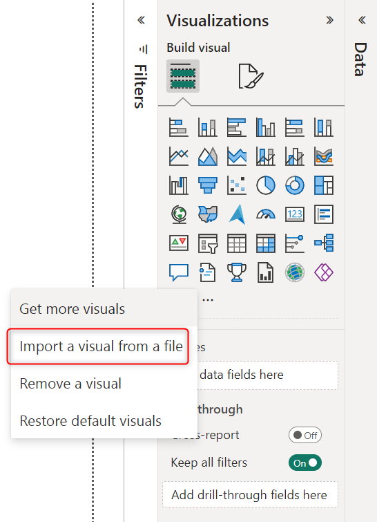

4. **Select “Import from file”**: Browse to the downloaded .pbiviz file
5. **Confirm Import**: Approve any security prompts that appear
6. **Verify Installation**: Check that the Inforiver icon appears in your visualization pane

[figure not shown]

This method is useful for controlled environments where AppSource access may be restricted or for testing specific versions before organizational deployment.

### Organizational Deployment

For enterprise-wide deployment, IT administrators can distribute Inforiver Analytics+ across the organization:

1. **Admin Portal Access**: Sign in to the Power BI Admin Portal
2. **Navigate to Tenant Settings**: Find the “Tenant settings” section
3. **Locate Visual Settings**: Go to “Developer settings” or “Organizational visuals”
4. **Add Organizational Visual**: Upload the Inforiver .pbiviz file
5. **Configure Access**: Set the appropriate access permissions
6. **Deployment**: The visual becomes available to all designated users

This approach provides centralized control over which versions of Analytics+ are available within the organization and ensures consistency across users.

### Power BI Report Server Deployment

For organizations using Power BI Report Server (on-premises), a specific deployment process is required:

1. **Obtain the Visual**: Download the .pbiviz file from Inforiver
2. **Local Storage**: Place the file in the designated Report Server visuals directory
3. **Configuration Update**: Modify the Report Server configuration to allow the visual
4. **Restart Services**: Restart the Report Server services as needed
5. **Verification**: Confirm the visual is available in Report Server reports

This method accommodates organizations with regulatory requirements that necessitate on-premises BI solutions.

## Licensing Options

Inforiver offers flexible licensing options to accommodate different organizational needs and usage scenarios:

### Licensing Tiers

#### Free Tier

- Basic visualization capabilities
- Limited chart types and features
- No commercial usage restrictions
- Data point limitations
- Community support only
- Suitable for evaluation and personal use

#### Standard Tier

- Enhanced visualization library
- Standard chart types and tables
- Commercial usage permitted
- Moderate data point capacity
- Email support
- Ideal for departmental deployment

#### Professional Tier

- Complete visualization library (100+ charts)
- Advanced analytical capabilities
- Enhanced performance with larger datasets
- Priority support
- Appropriate for enterprise analytics teams

#### Enterprise Tier

- Full feature access including planning capabilities
- Maximum data point capacity (30K+)
- Enterprise-grade support with SLAs
- Dedicated account management
- Training and implementation assistance
- Designed for organization-wide deployment

### Licensing Models

Inforiver Analytics+ offers several licensing models to accommodate different organizational preferences:

#### User-Based Licensing

- Per-user subscription model
- Assigned to specific named users
- Transferable between users with administration
- Clear cost structure based on team size
- Usage tracking and optimization possibilities
- Simplified license management for smaller teams

#### Capacity-Based Licensing

- Based on Power BI Premium capacity
- Unlimited users within the capacity
- Cost tied to infrastructure rather than user count
- Simplified administration for large deployments
- Ideal for enterprise-wide implementations
- Predictable cost structure regardless of user growth

#### Mixed Licensing

- Combination of user and capacity approaches
- Core team on user licenses
- Broader audience via capacity licensing
- Optimized cost structure for varied user intensity
- Flexible scaling as organizational needs evolve
- Customized licensing programs for complex requirements

### License Administration

Managing Inforiver Analytics+ licenses involves several key processes:

#### License Acquisition

1. **Purchase**: Via Inforiver website, direct sales, or partner channel
2. **License Key**: Receipt of license key or activation code
3. **Account Creation**: Establishment of Inforiver account for management
4. **Documentation**: Storage of license agreements and keys
5. **Renewal Configuration**: Setting up automatic or manual renewal processes

#### License Activation

1. **Admin Portal**: Access the Inforiver administration portal
2. **License Section**: Navigate to the license management area
3. **Key Entry**: Input the license key or activation code
4. **Validation**: Confirm license validation success
5. **Feature Enablement**: Verify activated features are accessible

#### User Assignment

1. **User Identification**: Determine which users require licenses
2. **Admin Portal**: Access user management interface
3. **Assignment**: Allocate licenses to specific users
4. **Notification**: Inform users of their license activation
5. **Verification**: Confirm users can access premium features

#### License Monitoring

1. **Usage Tracking**: Monitor actual usage against licensed capacity
2. **Compliance Checking**: Ensure adherence to license terms
3. **Expiration Management**: Track and plan for license renewals
4. **Optimization**: Identify opportunities to optimize license allocation
5. **Reporting**: Generate license usage reports for stakeholders

## Implementation Considerations

When implementing Inforiver Analytics+, several factors should be considered:

### Technical Requirements

For optimal performance, ensure your environment meets these requirements:

- **Power BI Desktop**: Latest version recommended
- **Browser**: Chrome, Edge, or Firefox (latest versions)
- **Network**: Reliable internet connection for cloud deployments
- **Memory**: Sufficient RAM for large dataset handling
- **Screen Resolution**: Minimum 1366x768 for optimal visualization display

## Deployment Best Practices

To ensure a successful deployment of Inforiver Analytics+, follow these best practices:

### Phased Rollout Approach

1. **Pilot Phase**: Deploy to a small group of power users
2. **Feedback Collection**: Gather input from pilot users
3. **Refinement**: Adjust configurations based on feedback
4. **Expanded Pilot**: Increase to a department-level deployment
5. **Organization Rollout**: Staged expansion to the broader organization

### User Enablement

1. **Role-Based Training**: Tailor training to different user roles
2. **Resource Library**: Create an internal knowledge base
3. **Champions Network**: Identify and empower internal experts
4. **Office Hours**: Schedule regular support sessions
5. **Feedback Mechanism**: Establish channels for ongoing user input

### Technical Configuration

1. **Performance Testing**: Validate performance with representative datasets
2. **Integration Verification**: Confirm seamless operation with existing Power BI reports
3. **Template Creation**: Develop standard templates for common scenarios
4. **Backup Procedures**: Ensure visualization configurations are backed up
5. **Monitoring Setup**: Implement performance and usage monitoring

## Upgrade and Maintenance

Maintaining your Inforiver Analytics+ implementation involves several ongoing processes:

### Version Management

1. **Release Monitoring**: Stay informed about new versions
2. **Testing Protocol**: Test new versions in a non-production environment
3. **Feature Evaluation**: Assess new capabilities for organizational relevance
4. **Controlled Rollout**: Implement version updates systematically
5. **Documentation**: Maintain records of version history

### License Maintenance

1. **Renewal Tracking**: Monitor license expiration dates
2. **Usage Evaluation**: Assess if current licensing meets evolving needs
3. **Cost Optimization**: Regularly review license allocation efficiency
4. **Vendor Communication**: Maintain relationship with Inforiver support
5. **Budget Planning**: Incorporate license costs in financial planning

## Troubleshooting Common Installation Issues

When deploying Inforiver Analytics+, you may encounter these common issues:

### Visual Not Appearing in Power BI Desktop

- **Cause**: Missing prerequisites or incomplete installation
- **Solution**: Verify Power BI Desktop version, check internet connectivity, and try reinstalling the visual

### License Activation Failure

- **Cause**: Incorrect license key or network connectivity issues
- **Solution**: Verify license key accuracy, check network connectivity, and contact Inforiver support if problems persist

### Version Compatibility Issues

- **Cause**: Mismatch between Power BI and Inforiver versions
- **Solution**: Update to compatible versions of both products and check release notes for known compatibility issues

### Performance Degradation

- **Cause**: Insufficient resources or large datasets
- **Solution**: Optimize dataset size, ensure adequate system resources, and follow performance best practices

### Features Not Available

- **Cause**: Licensing tier limitations or feature not enabled
- **Solution**: Verify your license includes the required features and check feature activation in the admin portal

By understanding the installation options, licensing models, and implementation best practices for Inforiver Analytics+, you can ensure a smooth deployment that maximizes the value of your investment in this powerful visualization and analytics solution.

In the next section, we’ll explore the first steps with Analytics+ and guide you through creating your initial visualizations and reports.

# 2.3 First Steps with Analytics+

After installing Inforiver Analytics+ in your Power BI environment, your next task is to begin working with the solution to create your first visualizations. This section guides you through the initial steps of using Analytics+, from adding the visual to your report to creating your first interactive visualization.

## Adding Analytics+ to Your Report

The first step in using Inforiver Analytics+ is to add it to your Power BI report:

1. **Create or Open a Power BI Report**: Either start a new report or open an existing one
2. **Connect to Data**: Ensure your report is connected to a data source
3. **Visualization Pane**: Locate the Visualizations pane on the right side of the screen
4. **Find Inforiver Analytics+**: Look for the Inforiver Analytics+ icon in the visualization gallery
5. **Add to Canvas**: Click on the Inforiver Analytics+ icon to add it to your report canvas
6. **Resize Visual**: Adjust the size and position of the visual on your canvas

[figure not shown]

Useful Links

Use the links in the visual for additional information:

- Getting started: Watch the video to get an overview of how Analytics+ works.
- Demo: This link navigates to the interactive demo page, where you can explore the different types of dashboards and charts that can be created with Analytics+.
- Documentation: Discover all the advanced reporting, visualization, and customization capabilities available in Analytics+.
- Pricing: Analytics+ offers different pricing tiers and plans you can use to purchase.

## Selecting the mode

The Analytics+ visual ships with different modes - chart, card, table, and Gantt. Each mode has a dedicated toolbar that contains customization options specific to it.

[figure not shown]

Selection

## Assign Data

For starters, you can assign the Axis and Values visual parameters. We’ve added a Small Multiples parameter in Card and Table mode to demonstrate the trellis feature in Analytics+. The parameters are the same for Chart, Card, and Table mode, but Gantt requires a different set of input parameters. Based on the data assigned, Analytics+ will create a default visualization. You can then customize and tailor the visual to suit your specific requirements.

**Chart mode**

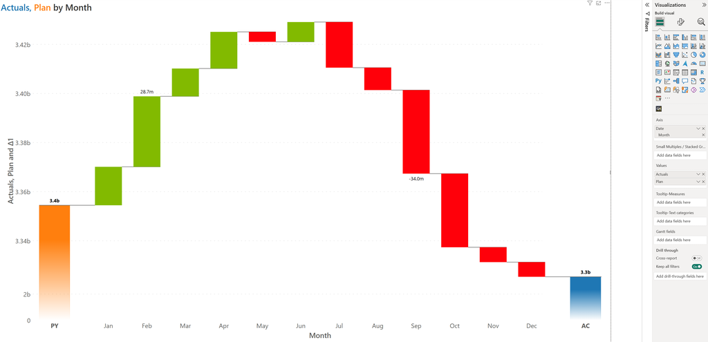

**Card mode**

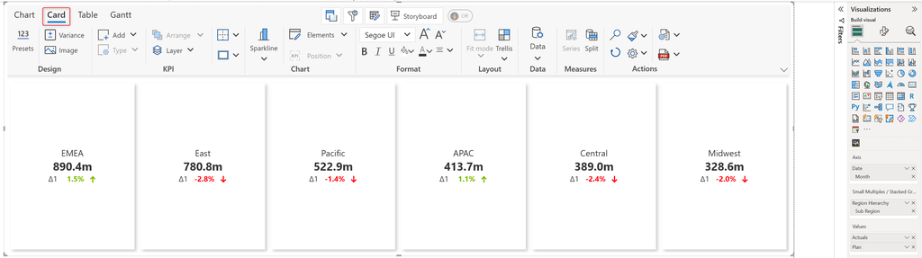

**Table mode**

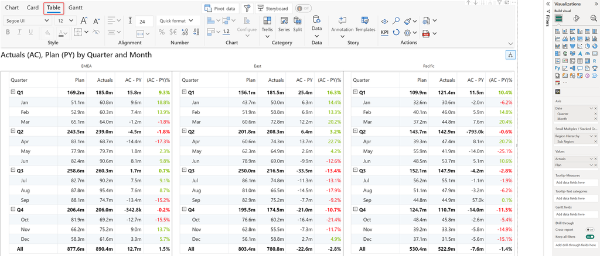

**Gantt mode**

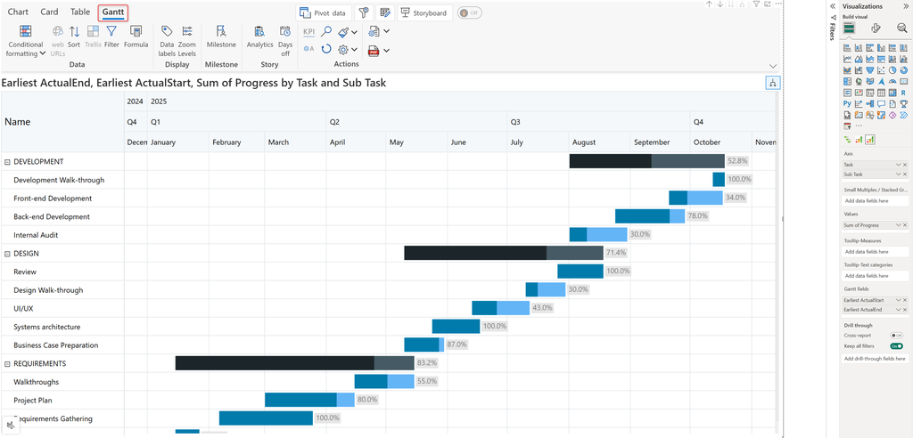

By following these first steps and guidance, you’ll quickly become comfortable with Inforiver Analytics+ and begin creating powerful, insightful visualizations that exceed the capabilities of native Power BI visuals.

In the next section, we’ll explore the interface of Analytics+ in greater detail, providing a comprehensive understanding of its navigation principles and key components.

# 2.4 Interface Overview and Navigation Principles

Inforiver Analytics+ features a sophisticated yet intuitive interface designed to balance power and usability. Understanding this interface is essential for efficiently navigating the platform and leveraging its full capabilities. This section provides a comprehensive overview of the Analytics+ interface and its underlying navigation principles.

## Interface Architecture

The Inforiver Analytics+ interface consists of several key components organized in a logical structure:

```
┌───────────────────────────────────────────────────────────────┐
│ Toolbar and Global Controls                                   │
├───────────┬───────────────────────────────────┬───────────────┤
│           │                                   │               │
│ Field     │                                   │ Configuration │
│ Selection │         Visualization Area        │     Panel     │
│ Panel     │                                   │               │
├───────────┴───────────────────────────────────┴───────────────┤
│ Status Bar / Information Area                                 │
└───────────────────────────────────────────────────────────────┘
```

This layout is designed to provide easy access to all necessary tools while maximizing the space available for your visualization.

Toolbar, data management, and visualization area:

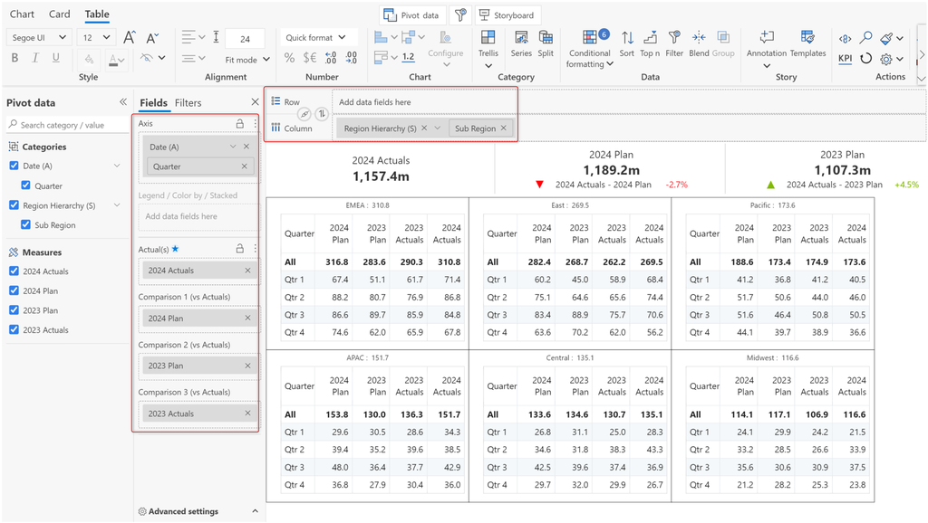

Layout

Configuration panel

[figure not shown]

Config Panel

Different visualization types in Analytics+ have specialized navigation features:

### Table and Matrix Navigation

When working with tabular visualizations:

- **Cell Selection**: Click to select individual cells

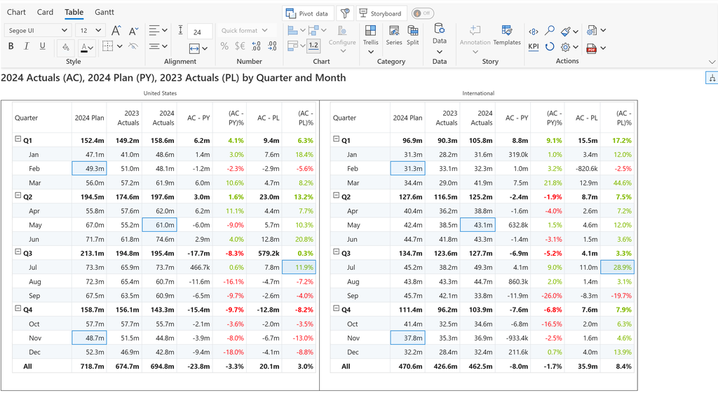

  Cell selection

- **Column/Row Headers**: Click headers to select entire columns or rows

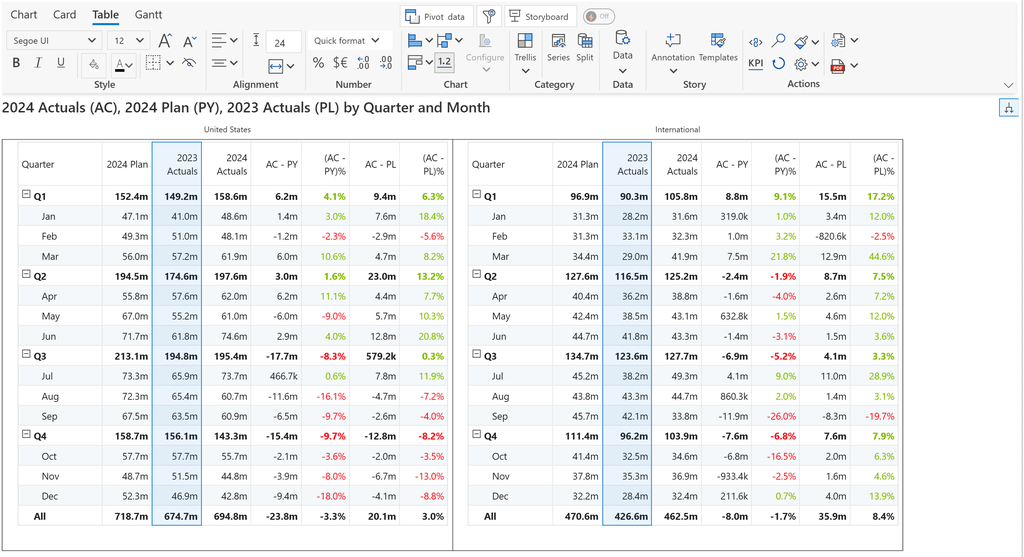

  Row and column headers

- **Resizing**: Drag column/row boundaries to resize
- **Sorting**: Click on headers to sort data

[figure not shown]

  Sort

- **Expanding/Collapsing**: Toggle hierarchical levels with +/- controls

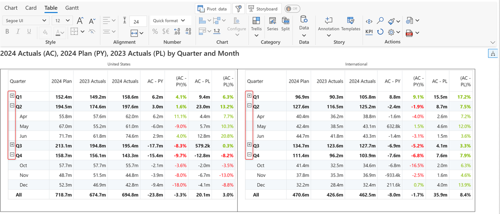

  Expand Collapse

- **Cell Editing**: Double-click or press F2 to edit cell content (in editable tables)

These table-specific interactions provide Excel-like control over tabular data.

### Chart Navigation

When working with graphical charts:

- **Data Point Selection**: Click data points to select them

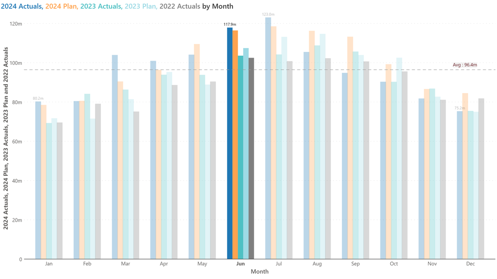

Data point selection

- **Series Selection**: Click on legend items to select entire series

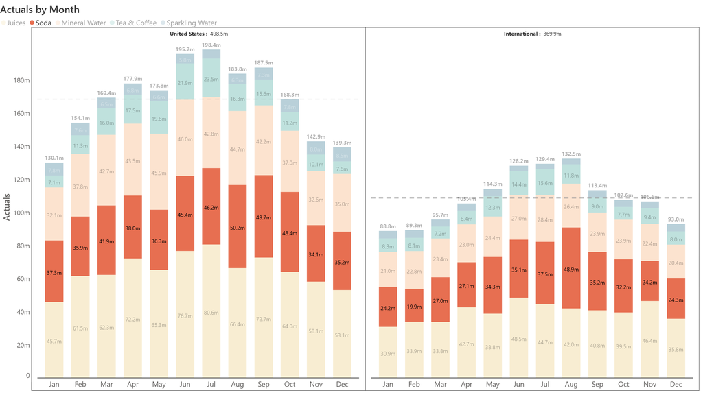

Legend based selection

- **Pan and Scroll**: Navigate through large datasets

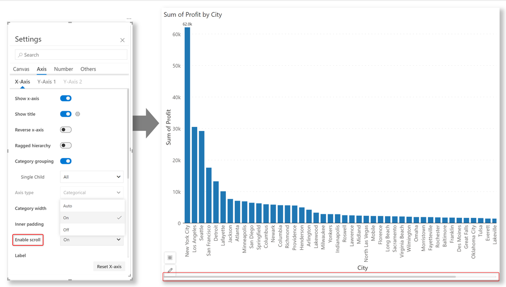

Scroll

- **Drill Operations**: Access drill-down and drill-up functionality for hierarchical datasets.

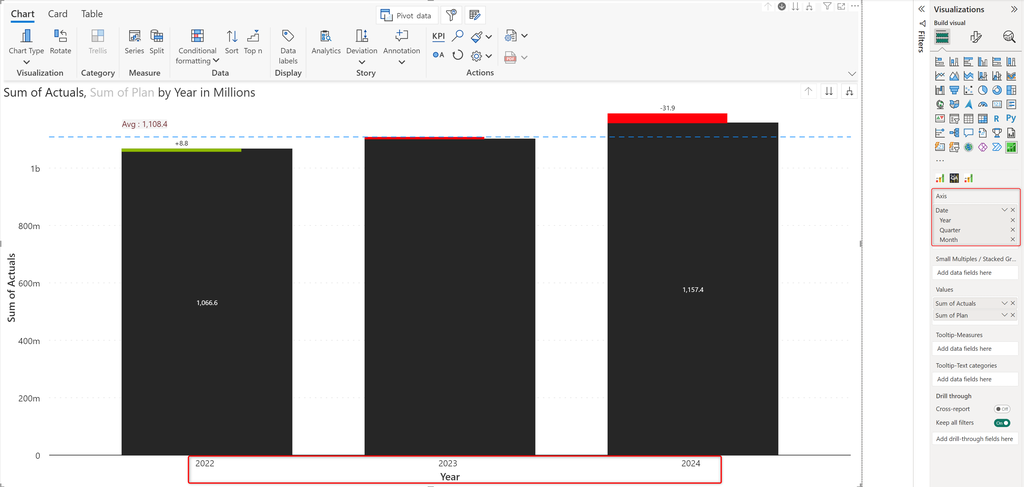

- **Lasso Selection**: Select multiple data points by drawing around them

[figure not shown]

Lasso

- **Sync Highlight**: The data points selected in one Analytics+ visual will be mirrored in other Analytics+ visuals and small multiple panels in the same visual

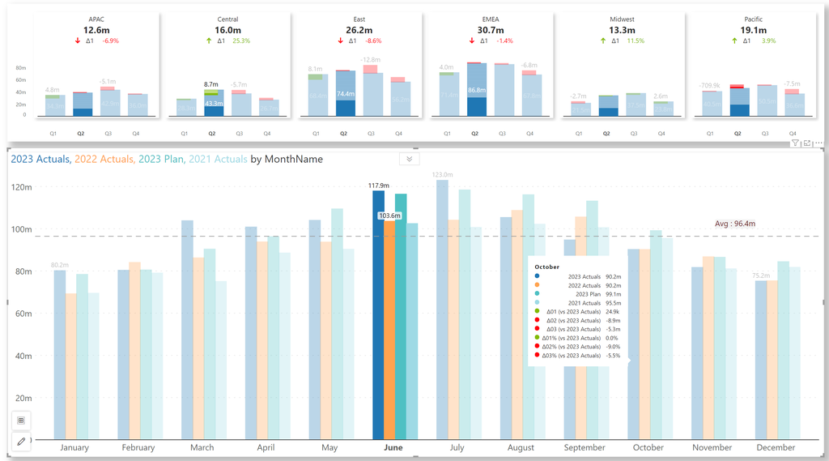

Sync Highlight

- **Chart Element Editing**: Directly manipulate chart elements with the on-object interaction menus.

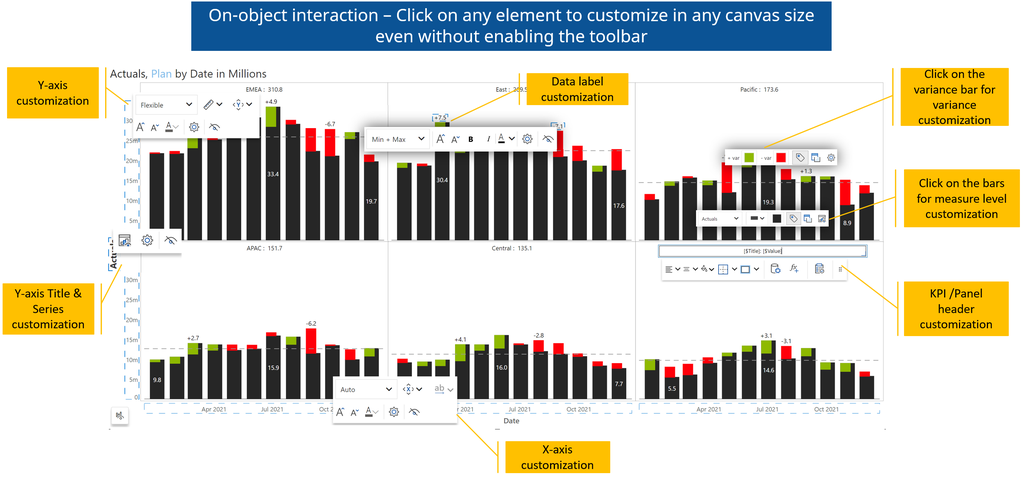

On-object interaction

These interactions enable exploration and refinement of visual charts.

### Small Multiples Navigation

When working with small multiples (trellis) visualizations:

- **Cross-Panel Selection**: Select the same element across multiple panels

[figure not shown]

  Cross panel selection

- **Panel Filtering**: Show/hide specific panels

[figure not shown]

  Panel filtering

- **Synchronization Controls**: Toggle synchronized scroll across panels for small multiple tables for side-by-side comparisons

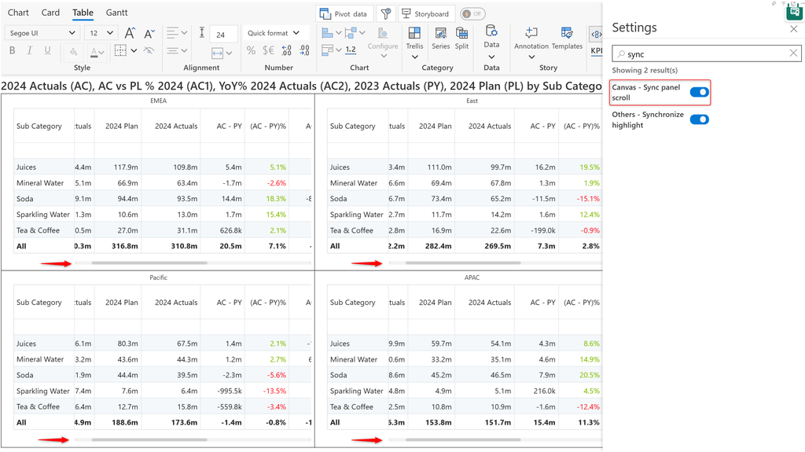

  Sync scroll

- **Layout Adjustment**: Modify the grid layout of panels

[figure not shown]

Layout adjustment

- **Panel Expansion**: Temporarily expand a panel for a detailed view

[figure not shown]

  Focus mode

These specialized controls help manage the complexity of small multiples displays.